# Problem Set 2

```r
#' Function to determine the end position of a random walk using loops
#'
#' @param n number of steps
#' @return The final position of the walk after `n` number of steps
random_walk1 <- function(n){
  cur <- 0
  probs <- 0.5 * c(0.95, 0.05, 0.8, 0.2)
  for (i in 1:n){
    step <- sample(c(1, 10, -1, -3), 1, prob = probs, replace = TRUE)
    cur <- cur + step
  }
  return(cur)
}

#' Function to determine the end position of a random walk using built-in R vectorized functions
#'
#' @param n number of steps
#' @return The final position of the walk after `n` number of steps
random_walk2 <- function(n){
  probs <- 0.5 * c(0.95, 0.05, 0.8, 0.2)
  steps <- sample(c(1, 10, -1, -3), n,  prob = probs, replace = TRUE)
  return (sum(steps))
}

#' Function to determine the end position of a random walk using sapply
#'
#' @param n number of steps
#' @return The final position of the walk after `n` number of steps
random_walk3 <- function(n){
  probs <- 0.5 * c(0.95, 0.05, 0.8, 0.2)
  steps <- sample(c(1, 10, -1, -3), n,  prob = probs, replace = TRUE)
  steps <- matrix(steps, nrow = 1)
  return(apply(steps, 1, sum))

}


random_walk1(10)
```

```
[1] -12
```

```r
random_walk2(10)
```

```
[1] 0
```

```r
random_walk3(10)
```

```
[1] 2
```

```r
random_walk1(1000)
```

```
[1] -28
```

```r
random_walk2(1000)
```

```
[1] -15
```

```r
random_walk3(1000)
```

```
[1] 65
```

### b

```r
set.seed(15)
random_walk1(10)
```

```
[1] 5
```

```r
set.seed(15)
random_walk2(10)
```

```
[1] 5
```

```r
set.seed(15)
random_walk3(10)
```

```
[1] 5
```

```r
set.seed(15)
random_walk1(1000)
```

```
[1] -86
```

```r
set.seed(15)
random_walk2(1000)
```

```
[1] -86
```

```r
set.seed(15)
random_walk3(1000)
```

```
[1] -86
```

### c

The results show that the vectorized function consistently outperforms the other implementations, such as loop and apply. The apply function is generally faster than explicit loops because it uses implicit looping internally.

```r
library(microbenchmark)
set.seed(123)
microbenchmark(
  loop = random_walk1(1000),
  vectorized = random_walk2(1000),
  apply = random_walk3(1000)
)
```

```
Unit: microseconds
       expr      min       lq       mean    median        uq      max neval
       loop 2470.701 2643.434 3033.17180 2737.5495 2889.3930 7211.367   100
 vectorized   20.213   21.156   23.11334   21.9760   24.3745   34.850   100
      apply   31.406   33.784   39.11810   37.1665   42.2300   69.126   100
```

```r
set.seed(123)
microbenchmark(
  loop = random_walk1(100000),
  vectorized = random_walk2(100000),
  apply = random_walk3(100000)
)
```

```
Unit: milliseconds
       expr        min         lq       mean     median         uq        max
       loop 273.520225 278.507670 284.289785 283.166725 287.522545 304.788875
 vectorized   1.737990   1.786288   1.808013   1.811585   1.825258   1.915479
      apply   2.159757   2.270560   2.319823   2.319165   2.362871   2.631093
 neval
   100
   100
   100
```

### d

The probability that the random walk ends at 0 is approximately 0.1355 when the number of steps is 10. For 100 steps, the probability decreases to around 0.0217, and for 1,000 steps, it drops further to about 0.0046.

```r
n_sim = 10000
result1 <- sapply(1:n_sim, function(i) random_walk2(10))

prob1 <- mean(result1 == 0)

result2 <- sapply(1:n_sim, function(i) random_walk2(100))
prob2 <- mean(result2 == 0)

result3 <- sapply(1:n_sim, function(i) random_walk2(1000))
prob3 <- mean(result3 == 0)
prob1
```

```
[1] 0.1355
```

```r
prob2
```

```
[1] 0.0217
```

```r
prob3
```

```
[1] 0.0046
```

## Problem 2

The average number of cars that pass an intersection per day is around 264.

```r
n <- 10000
n_sim <- n * c(8,8,6,2)
sim <- c(rpois(n_sim[1],1) , rpois(n_sim[2],8), rpois(n_sim[3],12), rnorm(n_sim[4],mean = 60,sd = sqrt(12)))
sum(sim)/n
```

```
[1] 263.9093
```

## Problem 3

### a

```r
youtube <- read.csv('https://raw.githubusercontent.com/rfordatascience/tidytuesday/master/data/2021/2021-03-02/youtube.csv')
youtube_clean <- youtube[, !(names(youtube) %in% c(
  "brand",
  "superbowl_ads_dot_com_url",
  "youtube_url",
  "id",
  "etag",
  "published_at",
  "channel_title",
  "thumbnail",
  "title",
  "description"
))]
dim(youtube_clean)
```

```
[1] 247  15
```

### b

1. N/A
2. View counts, Like counts, Dislike counts, Comment counts
3. Favorite counts

```r
cat("=======view_count========\n")
```

```
=======view_count========
```

```r
is.numeric(youtube_clean$view_count)
```

```
[1] TRUE
```

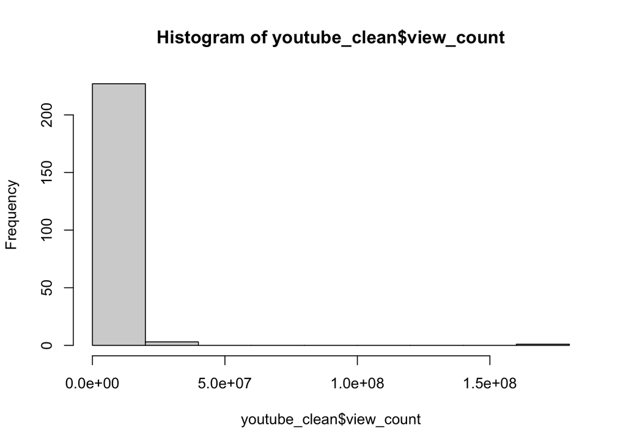

```r
hist(youtube_clean$view_count)
```

```r
table(youtube_clean$view_count, useNA = "ifany")
```

```
       10        21        42        56        79        92       111       125
        1         1         1         1         1         1         1         1
      136       139       162       179       186       198       236       293
        1         1         1         1         1         1         1         1
      301       319       350       394       487       518       546       561
        1         1         1         1         1         1         1         1
      782       788       907       987       998      1171      1190      1264
        1         1         1         1         2         1         1         1
     1294      1361      1460      1475      1874      2732      2801      2985
        1         1         1         1         1         1         1         1
     3183      3548      3667      3739      3754      3805      3900      4302
        4         1         1         1         1         1         1         1
     4641      4873      5049      5264      5699      6430      6432      6513
        1         1         1         1         1         1         1         1
     6641      6713      7253      7621      8990      9036      9335      9649
```

[output cut: 43 more lines]

```r
cat("=======like_count========\n")
```

```
=======like_count========
```

```r
is.numeric(youtube_clean$like_count)
```

```
[1] TRUE
```

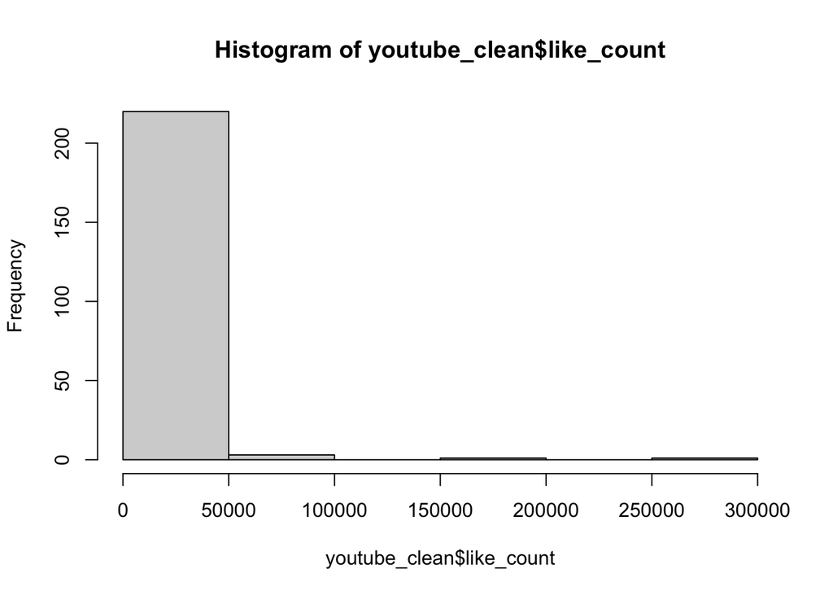

```r
hist(youtube_clean$like_count)
```

```r
table(youtube_clean$like_count, useNA = "ifany")
```

```
     0      1      2      3      4      5      6      7      8      9     10
     9      7      6      3      5      2      2      4      2      3      3
    12     13     14     15     18     19     20     22     26     27     29
     2      1      3      1      3      2      2      2      1      1      3
    32     33     36     37     39     40     42     45     46     47     49
     2      1      1      2      1      1      2      1      2      1      1
    51     53     60     63     65     67     68     69     70     71     74
     1      2      1      1      1      1      1      1      1      1      1
    78     86     91     92     93     97     99    100    103    109    115
     2      2      1      1      1      1      1      1      1      1      2
   118    120    121    129    130    133    138    140    144    146    151
     1      1      1      1      1      1      1      1      1      1      1
   154    161    163    167    171    178    198    199    200    202    216
     1      1      1      2      1      2      1      1      1      1      1
   217    219    221    222    224    229    232    235    244    266    268
```

[output cut: 17 more lines]

```r
cat("=======dislike_count========\n")
```

```
=======dislike_count========
```

```r
is.numeric(youtube_clean$dislike_count)
```

```
[1] TRUE
```

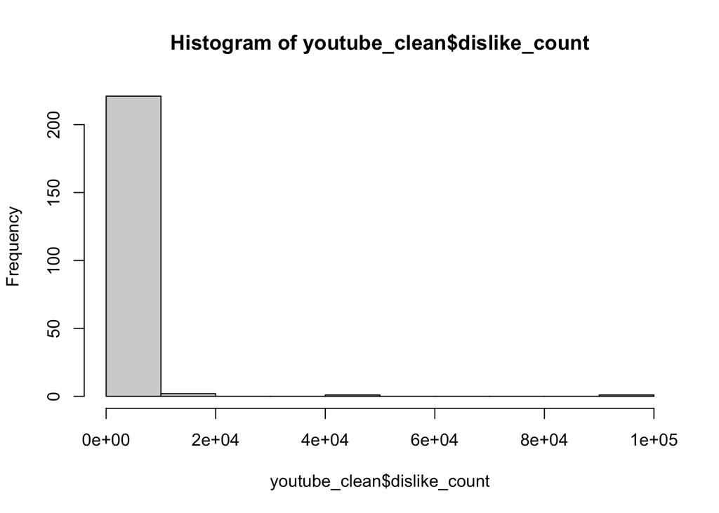

```r
hist(youtube_clean$dislike_count)
```

```r
table(youtube_clean$dislike_count, useNA = "ifany")
```

```
    0     1     2     3     4     5     6     7     8     9    10    11    12
   47    15    14    12     7     8     7    10     4     4     5     5     3
   13    14    15    16    18    19    22    23    24    27    28    30    31
    1     7     9     1     3     1     2     1     3     1     1     1     1
   37    38    42    49    54    56    58    60    62    64    73    74    78
    2     3     2     1     1     1     2     1     1     1     1     1     1
   88    94   100   108   117   121   130   134   138   149   159   178   180
    1     1     1     1     1     1     1     1     1     1     1     1     1
  181   203   215   222   296   323   359   384   521   556   576   861  1430
    1     1     1     1     2     1     1     1     1     1     1     1     1
 2015  2673  7445 12789 17113 42386 92990  <NA>
    1     1     1     1     1     1     1    22
```

```r
cat("=======favorite_count========\n")
```

```
=======favorite_count========
```

```r
is.numeric(youtube_clean$favorite_count)
```

```
[1] TRUE
```

```r
table(youtube_clean$favorite_count, useNA = "ifany")
```

```
   0 <NA>
 231   16
```

```r
cat("=======comment_count========\n")
```

```
=======comment_count========
```

```r
is.numeric(youtube_clean$comment_count)
```

```
[1] TRUE
```

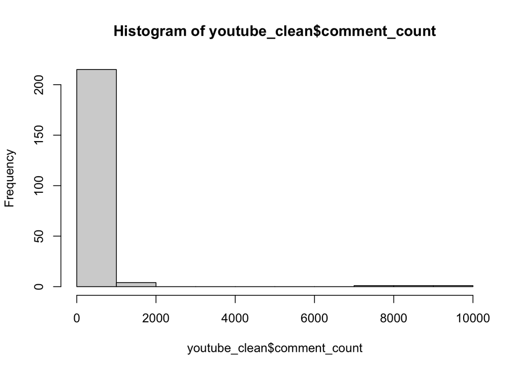

```r
hist(youtube_clean$comment_count)
```

```r
table(youtube_clean$comment_count, useNA = "ifany")
```

```
   0    1    2    3    4    5    6    7    8    9   10   11   12   13   14   15
  41   24   11    6    2    4    5    4    6    4    5    2    1    4    2    5
  16   17   18   21   23   24   25   26   28   29   30   32   33   35   36   37
   2    1    2    2    1    3    2    1    1    6    3    5    1    1    1    1
  38   42   45   46   50   51   52   53   56   57   59   65   67   71   73   75
   1    3    1    1    1    1    2    1    1    1    1    2    1    1    1    1
  82   83   84   88   94   95   96  104  114  118  119  139  150  160  162  180
   1    1    1    1    1    1    1    1    1    1    1    1    1    1    1    1
 184  194  201  204  206  208  226  227  231  261  271  279  304  319  324  376
   1    1    1    1    1    1    1    1    1    1    1    1    1    1    1    1
 523  592  607  813 1234 1373 1498 1828 7431 8441 9190 <NA>
   1    1    1    1    1    1    1    1    1    1    1   25
```

```r
youtube_clean$view_count_log     <- log1p(youtube_clean$view_count)
youtube_clean$like_count_log     <- log1p(youtube_clean$like_count)
youtube_clean$dislike_count_log  <- log1p(youtube_clean$dislike_count)
youtube_clean$comment_count_log  <- log1p(youtube_clean$comment_count)
```

### c

Based on the p-values of the estimated coefficients, year has a statistically significant effect on like_count, dislike_count, and comment_count at the 5% level. Holding all other variables constant, a one-year increase is associated with an estimated 0.075 increase in log(like_count), a 0.09337 increase in log(dislike_count), and a 0.053 increase in log(comment_count).

Similarly, patrioticTRUE is statistically significant for comment_count at the 5% level. Holding other factors constant, ads labeled as patriotic are associated with an estimated 0.935 higher log(comment_count) compared to non-patriotic ads.

```r
youtube_clean <- na.omit(youtube_clean)
dim(youtube_clean)
```

```
[1] 219  19
```

```r
mod1 <- lm(view_count_log ~ year + funny + show_product_quickly + patriotic + celebrity + danger + animals + use_sex, youtube_clean)
mod2 <- lm(like_count_log ~ year + funny + show_product_quickly + patriotic + celebrity + danger + animals + use_sex, youtube_clean)
mod3 <- lm(dislike_count_log ~ year + funny + show_product_quickly + patriotic + celebrity + danger + animals + use_sex, youtube_clean)
mod4 <- lm(comment_count_log ~ year + funny + show_product_quickly + patriotic + celebrity + danger + animals + use_sex, youtube_clean)

summary(mod1)
```

```
Call:
lm(formula = view_count_log ~ year + funny + show_product_quickly +
    patriotic + celebrity + danger + animals + use_sex, data = youtube_clean)

Residuals:
    Min      1Q  Median      3Q     Max
-8.2357 -1.6062  0.2332  1.6347  8.5156

Coefficients:
                          Estimate Std. Error t value Pr(>|t|)
(Intercept)              -40.95957   71.99742  -0.569   0.5700
year                       0.02506    0.03580   0.700   0.4847
funnyTRUE                  0.75181    0.47416   1.586   0.1143
show_product_quicklyTRUE   0.26142    0.41192   0.635   0.5264
patrioticTRUE              0.97186    0.56177   1.730   0.0851 .
celebrityTRUE              0.18693    0.43423   0.430   0.6673
dangerTRUE                 0.61824    0.42558   1.453   0.1478
animalsTRUE               -0.05894    0.40193  -0.147   0.8836
use_sexTRUE               -0.37680    0.45396  -0.830   0.4075
---
Signif. codes:  0 '***' 0.001 '**' 0.01 '*' 0.05 '.' 0.1 ' ' 1

Residual standard error: 2.77 on 210 degrees of freedom
Multiple R-squared:  0.03866,   Adjusted R-squared:  0.002034
F-statistic: 1.056 on 8 and 210 DF,  p-value: 0.3957
```

```r
summary(mod2)
```

```
Call:
lm(formula = like_count_log ~ year + funny + show_product_quickly +
    patriotic + celebrity + danger + animals + use_sex, data = youtube_clean)

Residuals:
    Min      1Q  Median      3Q     Max
-5.3142 -1.6615  0.0629  1.5222  7.7576

Coefficients:
                           Estimate Std. Error t value Pr(>|t|)
(Intercept)              -146.83814   64.04727  -2.293   0.0229 *
year                        0.07496    0.03185   2.354   0.0195 *
funnyTRUE                   0.53109    0.42180   1.259   0.2094
show_product_quicklyTRUE    0.24669    0.36643   0.673   0.5016
patrioticTRUE               0.83252    0.49974   1.666   0.0972 .
celebrityTRUE               0.46322    0.38628   1.199   0.2318
dangerTRUE                  0.61730    0.37858   1.631   0.1045
animalsTRUE                 0.01964    0.35755   0.055   0.9563
use_sexTRUE                -0.42519    0.40383  -1.053   0.2936
---
Signif. codes:  0 '***' 0.001 '**' 0.01 '*' 0.05 '.' 0.1 ' ' 1

Residual standard error: 2.464 on 210 degrees of freedom
Multiple R-squared:  0.07503,   Adjusted R-squared:  0.03979
F-statistic: 2.129 on 8 and 210 DF,  p-value: 0.03444
```

```r
summary(mod3)
```

```
Call:
lm(formula = dislike_count_log ~ year + funny + show_product_quickly +
    patriotic + celebrity + danger + animals + use_sex, data = youtube_clean)

Residuals:
    Min      1Q  Median      3Q     Max
-4.0598 -1.3531 -0.3356  0.8925  8.7463

Coefficients:
                           Estimate Std. Error t value Pr(>|t|)
(Intercept)              -185.75848   53.85611  -3.449 0.000679 ***
year                        0.09337    0.02678   3.486 0.000596 ***
funnyTRUE                   0.28909    0.35469   0.815 0.415959
show_product_quicklyTRUE    0.30748    0.30812   0.998 0.319467
patrioticTRUE               0.81048    0.42022   1.929 0.055116 .
celebrityTRUE              -0.15241    0.32481  -0.469 0.639397
dangerTRUE                  0.24992    0.31834   0.785 0.433301
animalsTRUE                -0.12707    0.30065  -0.423 0.672979
use_sexTRUE                -0.30380    0.33957  -0.895 0.371992
---
Signif. codes:  0 '***' 0.001 '**' 0.01 '*' 0.05 '.' 0.1 ' ' 1

Residual standard error: 2.072 on 210 degrees of freedom
Multiple R-squared:  0.09959,   Adjusted R-squared:  0.06529
F-statistic: 2.904 on 8 and 210 DF,  p-value: 0.00432
```

```r
summary(mod4)
```

```
Call:
lm(formula = comment_count_log ~ year + funny + show_product_quickly +
    patriotic + celebrity + danger + animals + use_sex, data = youtube_clean)

Residuals:
    Min      1Q  Median      3Q     Max
-4.4404 -1.5468 -0.1288  1.4067  5.7345

Coefficients:
                           Estimate Std. Error t value Pr(>|t|)
(Intercept)              -105.20432   52.58596  -2.001   0.0467 *
year                        0.05329    0.02615   2.038   0.0428 *
funnyTRUE                   0.30098    0.34632   0.869   0.3858
show_product_quicklyTRUE    0.46561    0.30086   1.548   0.1232
patrioticTRUE               0.93540    0.41031   2.280   0.0236 *
celebrityTRUE               0.39475    0.31715   1.245   0.2146
dangerTRUE                  0.21290    0.31083   0.685   0.4941
animalsTRUE                -0.17886    0.29356  -0.609   0.5430
use_sexTRUE                -0.35786    0.33157  -1.079   0.2817
---
Signif. codes:  0 '***' 0.001 '**' 0.01 '*' 0.05 '.' 0.1 ' ' 1

Residual standard error: 2.023 on 210 degrees of freedom
Multiple R-squared:  0.0816,    Adjusted R-squared:  0.04661
F-statistic: 2.332 on 8 and 210 DF,  p-value: 0.02029
```

### d

```r
X <- model.matrix(view_count_log ~ year + funny + show_product_quickly + patriotic + celebrity + danger + animals + use_sex, data = youtube_clean)
beta1 <- solve(t(X)%*%X)%*%t(X)%*%youtube_clean$view_count_log
beta1
```

```
                                 [,1]
(Intercept)              -40.95956692
year                       0.02505906
funnyTRUE                  0.75180700
show_product_quicklyTRUE   0.26141786
patrioticTRUE              0.97186446
celebrityTRUE              0.18693308
dangerTRUE                 0.61824418
animalsTRUE               -0.05894022
use_sexTRUE               -0.37679568
```

```r
#X2 <- model.matrix(like_count_log ~ year + funny + show_product_quickly + patriotic + celebrity + danger + animals + use_sex, youtube_clean)
beta2 <- solve(t(X)%*%X)%*%t(X)%*%youtube_clean$like_count_log
beta2
```

```
                                  [,1]
(Intercept)              -146.83814292
year                        0.07496454
funnyTRUE                   0.53108667
show_product_quicklyTRUE    0.24668521
patrioticTRUE               0.83251860
celebrityTRUE               0.46322394
dangerTRUE                  0.61729927
animalsTRUE                 0.01963578
use_sexTRUE                -0.42518886
```

```r
#X3 <- model.matrix(dislike_count_log ~ year + funny + show_product_quickly + patriotic + celebrity + danger + animals + use_sex, youtube_clean)
beta3 <- solve(t(X)%*%X)%*%t(X)%*%youtube_clean$dislike_count_log
beta3
```

```
                                  [,1]
(Intercept)              -185.75848068
year                        0.09336774
funnyTRUE                   0.28909151
show_product_quicklyTRUE    0.30748273
patrioticTRUE               0.81047828
celebrityTRUE              -0.15241062
dangerTRUE                  0.24991875
animalsTRUE                -0.12707306
use_sexTRUE                -0.30380331
```

```r
#X4 <- model.matrix(comment_count_log ~ year + funny + show_product_quickly + patriotic + celebrity + danger + animals + use_sex, youtube_clean)
beta4 <- solve(t(X)%*%X)%*%t(X)%*%youtube_clean$comment_count_log
beta4
```

```
                                  [,1]
(Intercept)              -105.20431508
year                        0.05328517
funnyTRUE                   0.30098381
show_product_quicklyTRUE    0.46560536
patrioticTRUE               0.93539803
celebrityTRUE               0.39475257
dangerTRUE                  0.21289849
animalsTRUE                -0.17886023
use_sexTRUE                -0.35785549
```